# はじめに

深層学習（Deep Learning、ディープ・ラーニング）は、とても簡単です[^1]。簡単な理由は、以下の2つ。

1. TensorFlowやChainerといったライブラリが抽象化したAPIを提供するので、詳細（コムズカシイ数式等）を理解していなくても使える。
2. 汎用性が高いため、いわゆる統計処理や機械学習のような複数のアルゴリズムの使い分けが不要。必要な前提知識が少なくて済む。

もし嘘だと思うなら、「2. インストール」の記述に従ってTensorFlowをインストールして、「4. プログラムの作成」で紹介する深度センサーのデータからの一般物体認識プログラムを実行してみてください。簡単（数式はゼロ！）な短い（全部で185行！）プログラムなのに、深度センサーの前に置かれたものが何なのかを高い精度（90%以上！）で答えてくれます。

深層学習がどのように動作するのかは、「3. 深層学習の仕組み」で述べます。ここを読んで深層学習の仕組みを理解すれば、先程の「4. プログラムの作成」のソース・コードを少し修正するだけで、すぐに深層学習を活用する新たなサービスを作成できます。

深層学習は本当に簡単で、しかも有用です。「よく分からないけれど難しそう」という理由で使わないのはあまりにもったいない。深層学習をじゃんじゃん使って、鼻歌交じりに人工知能してみませんか？ かなり面白いですよ。

# インストール

本章では、深層学習のライブラリの1つであるGoogleの[TensorFlow](https://www.tensorflow.org/)と、TensorFlowの実行に必要な[Python](https://www.python.jp)をインストールします。

インストール先となるOSは、シェアが最も高いWindowsとしましょう。

## Pythonのインストール

まずは、プログラミング言語のPythonをインストールします。科学技術コンピューティングといえばPythonですもんね。

### Pythonのバージョンは、3.x系で

Pythonには2.x系と3.x系という互換性がない2つのバージョンがあって、だからどちらにしようか迷うことが多いようですけど、本稿では3.x系を選択します。

3.x系の良いところは、2.x系との互換性を捨て去ることで得た一貫性のある分かりやすい言語仕様です。そして悪いところは、世の中には2.x系にしか対応していないライブラリがあって、それらが使えないこと……なのですけど、本稿が使用するTensorFlowは、Windows環境では3.xにしか対応していないというまさかの逆パターンなんですよ。というわけで、無条件で3.xとなります。

### Python 3.5.3のインストール

Webブラウザーでhttps://www.python.org/を開き、一番下までスクロールして、Downloadsの[Windows]リンクをクリックしてください。

[figure not shown]

[figure not shown]

ダウンロードした「python-3.5.3-amd64.exe」を実行して、[Install Now]をクリックしてください。

[figure not shown]

以下のウィンドウが表示されたら、インストールは完了です。

[figure not shown]

### venvで、TensorFlow用の仮想環境を作る

実は素のPythonだけでできることは少なくて、だから多数のライブラリを追加してできることを増やしていきます。TensorFlowだって、そのライブラリの一つですもんね。

でも、多数のライブラリをインストールすると、ライブラリ間で競合が発生してしまうかもしれません。そもそも、Pythonのバージョンだって複数必要になるかもしれませんしね（もしTensorFlowを使わないなら、最新のPythonの3.6.xを使ってみたいでしょ？）。この問題を避けるには、適当な単位（プロジェクト単位等）で仮想環境を作ってあげればオッケー。Pythonの3.x系には仮想環境を作るための`venv`というツールが付属していますから、それを使用しましょう。

というわけで、コマンドプロンプトを起動して適当なディレクトリ（Documents等）に移動し、以下のコマンドを実行してください。

```bash
> %HOMEDRIVE%%HOMEPATH%\AppData\Local\Programs\Python\Python35\python -m venv TensorFlow
```

上のコマンドを実行すると、TensorFlowというディレクトリが作成されます。このディレクトリが、Pythonの仮想環境になります。

仮想環境をアクティブにするには、作成したTensorFlowディレクトリに移動して`scripts\activate`を実行します。

```bash
> cd TensorFlow
> scripts\activate
```

仮想環境がアクティブになると、プロンプトが`(TensorFlow) >`のように変わります。仮想環境がアクティブになれば、先ほどのように長いパスを入力しなくても、ただ`python`と入力するだけでPythonのインタープリターが起動します。

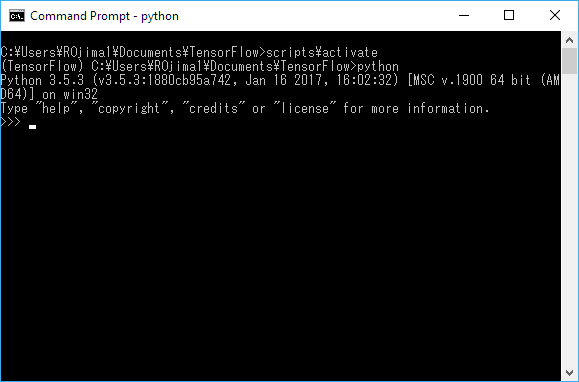

起動したPythonのインタープリターを終了したい場合は、`exit()`と入力してください。

## TensorFlowのインストール

深層学習のライブラリとしては、2017年3月現在ならTensorFlowかChainerのどちらかを選んでおけば間違いなく幸せになれます。本稿では、筆者の独断でTensorFlowとします。強いて理由を挙げるなら、Google製なので寄らば大樹みたいな安心感があるところかなぁと[^2]。

### pip

ライブラリのWebサイトを開いてインストール・プログラムをダウンロードしてインストール、そのライブラリが依存するライブラリについても漏れ無く同様の手順を実行しておいてね……という大昔のJavaみたいな環境構築作業はやってられないので、今時の言語にはたいていライブラリを管理するシステムが付属しています（Rubyならgem、Haskellならcabal）。Pythonの場合は、`pip`というコマンドでライブラリを管理するのが一般的です。TensorFlowも、この`pip`で簡単にインストールできます。

というわけで、Pythonのインストール時に作成した仮想環境をアクティブ化して、以下のコマンドを実行してください[^3]。

```bash
(TensorFlow) > pip install tensorflow
```

これだけで、TensorFlowの実行に必要なNumPyなどの他のライブラリも含めた全てが、一括でインストールされます。

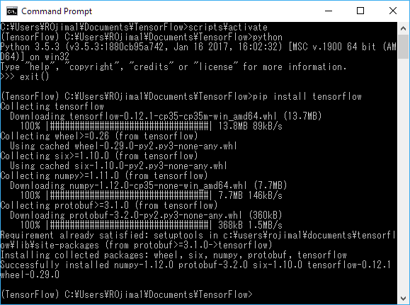

これで終了。正しくインストールされたか、確認してみましょう。TensorFlowを使用して、`1 + 1`を計算してみます。

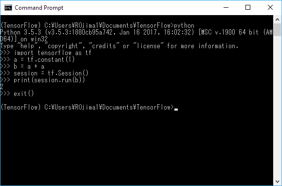

はい、`1 + 1`の計算結果である`2`が表示されました。深層学習する準備は、これで完璧ですね。

# 深層学習とは？

TensorFlowの環境ができたから、さっそくプログラミング……の前に、深層学習とはどんなものなのか、その概要を述べさせてください。4章のコードをコピー＆ペーストしてテキトーに修正するだけでもTensorFlowを使用した深層学習はできちゃうのですけど、概要を理解していた方が、より良く深層学習できますもんね。

## 形式ニューロン

まずは、基礎から。深層学習はニューラル・ネットワークを学習させるテクニックなので、そのニューラル・ネットワークを構成する要素であるニューロンの話から始めさせてください。

生物のニューロンは、その細胞体から何本も生えた樹状突起で刺激を受け取って、なんだかよくわからない基準でいい感じに刺激群を判断して、軸索を通じて次のニューロンに刺激を送ったり送らなかったりします。こんなのがいっぱい集まって、私達の脳はできあがっているんだって。

Pythonのコードにすると、以下のような感じ。

```python
weights = (5, 2, 2)  # 重み
threshold = 3  # しきい値


# 形式ニューロン
def formal_neuron(*xs):  # xsは3つの真偽値
    # 真である場合の重みを足しあわせて、しきい値を超えたら真。そうでなければ偽。
    return sum(weights[i] for i, x in enumerate(xs) if x) > threshold
```

この形式ニューロン、こんな単純な構造のくせに、なかなかいい感じに判断してくれるんですよ。

具体的にいきましょう。先ほどのコードの`formal_neuron`に、私が今週末に遊びに行くかどうかを表現させてみます。引数である`xs`を構成する3つの真偽値は、それぞれ「晴れている」、「読むべき本がない」、「やらなければならない仕事がない」とします（否定形でわかりづらくてごめんなさい。マイナスの数字を使うのは、私には難しかったの……）。

私の趣味はオートバイに乗ることで、そして独身で家族いなくてコミュ症で友達いません。だから、晴れていれば（他の条件がどうであっても）オートバイでツーリングに行きます。確認してみましょう。

```python
>>> formal_neuron(True, False, False)  # 晴れ、本あり、仕事あり。
True  # 遊びに行く
>>>
```

私は、読むべき有益な本があっても仕事が残っていても、晴れていればオートバイで出かけちゃう阿呆だということがわかりました。光に反応する昆虫みたいですな。

でも、雨が降ったらどうなるのでしょうか？ 続けて試してみましょう。

```python
>>> formal_neuron(False, True, False)  # 雨、本なし、仕事あり。
False  # 遊びに行かない。
>>> formal_neuron(False, False, True)  # 雨、本あり、仕事なし。
False  # 遊びに行かない。
>>> formal_neuron(False, True, True)   # 雨、本なし、仕事なし。
True   # 遊びに行く。
>>>
```

なるほど、まだ読んでいない本があるならそれを読む、仕事があるなら仕事をする、どちらもないなら、雨であってもカッパを着てオートバイに乗るわけですね。こんな単純なコードなのに、いい感じに判断できていて面白いでしょ？

でも、もっと面白いことがあるんです。重みである`weights`としきい値である`threshold`を調整するだけで、私とは異なる人の場合も表現できるんですよ。たとえば、しきい値を`4`にすれば（`threshold = 4`）、晴れていれば遊びに行くけど雨ならば何があっても遊びに行かないという、雨が嫌いなオートバイ大好き人間になります。晴れの重みを減らして本の重みを増やしたなら（`weights = [2, 5, 2]`）、ビブリオマニアの読子＝リードマンさんですね。

形式ニューロンは、ANDとOR、NOTなんてのも表現できます。形式ニューロンを多段に組み合わせて良いのであれば、XORも表現できます。

```python
from itertools import chain


def and_(*xs):
    # weightsとthresholdは、関数内に埋め込んでいます。
    return sum((1, 1)[i] for i, x in enumerate(xs) if x) > 1.5


def or_(*xs):
    return sum((1, 1)[i] for i, x in enumerate(xs) if x) > 0.5


def not_(*xs):
    return sum((-1,)[i] for i, x in enumerate(xs) if x) > -0.5


def xor_(*xs):
    def next_layer(*next_xs):
        return sum((1, 1, -2)[i] for i, x in enumerate(next_xs) if x) > 0.5

    return next_layer(*chain(xs, ((sum((1, 1)[i] for i, x in enumerate(xs) if x) > 1.5),)))
```

スゲー。ANDとORとNOTとXORを表現できるってことは、つまり、どんな電子回路でも作れるってことです。形式ニューロンを集めれば、CPUを作れちゃうんですよ。

これなら、もっとスゴイこともできそうです。適切な重みとしきい値を持った形式ニューロンをいい感じに積み重ねていけば、CPUよりもスゴイ、生物の脳と同様の判断、たとえば網膜に映った画像から餌の有無を判断したりできるかもしれません。だって、形式ニューロンは生物のニューロンを模しているんですから！

## 単純パーセプトロン

……ごめんなさい。そうは問屋が卸してくれませんでした。だって、パラメーター設定が難しすぎますもん。前節のXORのコードを書けたのは、Wikipediaの形式ニューロンの説明の中にパラメーターが載っていたからで、私が頑張ってパラメーターを設定したからではありません。XOR程度でこれなのですから、画像認識のためのパラメーター調整なんてのは、人間がやれる作業じゃあないですよ。

では、どうするか？ 人間ができないなら、機械にやらせてしまえばよいわけです。そのために、1957年にローゼンブラットさんがパーセプトロンを発明しました。

パーセプトロンをコードにすると、以下のようになります。形式ニューロンとの違いは、入力値の要素と重みの要素を掛け算するようになったのと、しきい値（`threshold`）がバイアス（`bias`）と改名されて比較演算子の左に移動した程度。あと、掛け算をするので、入力値は実数になるところ。なお、機械学習するんだからパラメーター調整は私がやらなくても良いので、以下のコードでは重みもバイアスも適当な値にしてあります。

```python
weights = (0.0, 1.0)  # 重み
bias = -0.5  # バイアス


def perceptron(*xs):
    return 1 if sum(x * weight for x, weight in zip(xs, weights)) + bias >= 0 else 0
```

パーセプトロンの良い所は、重みやバイアスを調整しやすいところです。

形式ニューロンだと、判断に間違えた時に、重みやバイアスをどの程度変更したらよいのかが分からないですよ。でも、パーセプトロンなら、`x * weights`になっていますから、`x`に関係した数値で`weight`を増減させてあげればよさそうに思えます。`bias`については、`x`が1だとみなしちゃえばよいでしょう。

方針が定まったので、このパーセプトロンを実際に機械学習させます。今回は、昭和の男の子がみんな大好きだったスーパー・カーのオートバイ版であるスーパー・スポーツ（とにかく速くて馬鹿っぽいオートバイだと思ってください）の判別とします。上のコードでは重みが2個なので`xs`の数は2つ、オートバイを表現する数値2つということで、エンジンの大きさ（排気量）と価格を入力にします。

さっそく、日本のバイクメーカーであるホンダとヤマハとカワサキと私が愛するスズキのスーパー・スポーツなオートバイのデータを集めてきました。判断のためにはスーパー・スポーツでは「ない」オートバイも必要ですから、2016年の販売台数トップ10（400cc以上）の中から国産のオートバイを抜き出したものも付け加えます。あと、もちろん機械学習と学習結果検証のコードが必要で、パーセプトロンの機械学習がどのように進むのかを可視化するコードもあったほうがよいでしょう。

というわけで、以下のコードを作ってきました。

```python
import matplotlib.pyplot as plot  # 動かす前に、pip install matplotlibしておいてください。
import matplotlib.animation as animation

from itertools import starmap
from random import shuffle


weights = (0.0, 1.0)  # 重み
bias = -0.5  # バイアス


# パーセプトロン。
def perceptron(*xs):
    # 入力と重みを掛け算して足しあわせてバイアスを足した結果が0以上なら1、そうでなければ0を返します。
    return 1 if sum(x * weight for x, weight in zip(xs, weights)) + bias >= 0 else 0


# 機械学習用のデータ。
motorcycles = (
    # ひとつ目の要素が1なら、スーパー・スポーツ。ふたつ目の要素は、排気量と価格のタプル。
    (1, ( 999, 1501200)),  # ホンダ CBR1000RR（ロスホワイト）
    (1, ( 999, 1468800)),  # ホンダ CBR1000RR
    (1, ( 999, 1674000)),  # ホンダ CBR1000RR<ABS>（ロスホワイト）
    (1, ( 999, 2030400)),  # ホンダ CBR1000RR SP
    (1, ( 599, 1334880)),  # ホンダ CBR600RR<ABS>（ロスホワイト）
    (1, ( 599, 1162080)),  # ホンダ CBR600RR（ロスホワイト）
    (1, ( 599, 1302480)),  # ホンダ CBR600RR<ABS>（グラファイトブラック）
    (1, ( 599, 1129680)),  # ホンダ CBR600RR（グラファイトブラック）
    (1, ( 998, 2430000)),  # ヤマハ YZF-R1（ライトれディッシュイエローソリット1）
    (1, ( 998, 2376000)),  # ヤマハ YZF-R1（ディープパープリッシュブルーメタリックC）
    (1, ( 998, 3186000)),  # ヤマハ YZF-R1M
    (1, ( 998, 1782000)),  # カワサキ Ninja ZX-10R
    (1, ( 599,  924480)),  # カワサキ Ninja ZX-6R
    (1, ( 999, 1695600)),  # スズキ GSX-R1000
    (1, ( 999, 1760400)),  # スズキ GSX-R1000 ABS
    (1, ( 750, 1544400)),  # スズキ GSX-R750
    (1, ( 599, 1425600)),  # スズキ GSX-R600

    # ひとつ目の要素が0なら、スーパースポーツではない。
    (0, ( 845, 1069200)),  # ヤマハ MT-09 TRACER ABS
    (0, ( 745,  743040)),  # ホンダ NC750X
    (0, ( 745,  793800)),  # ホンダ NC750X<ABS>
    (0, ( 745,  859680)),  # ホンダ NC750X DCS<ABS>
    (0, ( 745,  924480)),  # ホンダ NC750X DCS<ABS> E Package
    (0, ( 845, 1004400)),  # ヤマハ MT-09 ABS
    (0, ( 998, 1382400)),  # ホンダ CRF1000L（ヴィクトリーレッド、パールグレアホワイト）
    (0, ( 998, 1350000)),  # ホンダ CRF1000L（キャンディープロミネンスレッド、デジタルシルバーメタリック）
    (0, ( 998, 1490400)),  # ホンダ CRF1000L DCS（ヴィクトリーレッド、パールグレアホワイト）
    (0, ( 998, 1458000)),  # ホンダ CRF1000L DCS（キャンディープロミネンスレッド、デジタルシルバーメタリック）
    (0, ( 998, 1115640)),  # スズキ GSX-S1000 ABS
    (0, ( 998, 1166400)),  # スズキ GSX-S1000F ABS
    (0, ( 688,  760320)),  # ヤマハ MT-07 ABS
    (0, ( 688,  710640)),  # ヤマハ MT-07
    (0, ( 845, 1042200)),  # ヤマハ XSR900
    (0, (1164, 1172880)))  # カワサキ ZRX1200 DAEG


# 機械学習します。
def train():
    global weights, bias

    # 排気量と価格を、0〜1の間の数値に正規化します。
    min_xs = tuple(min(starmap(lambda _, xs: xs[i], motorcycles)) for i in range(2))
    max_xs = tuple(max(starmap(lambda _, xs: xs[i], motorcycles)) for i in range(2))
    normalized_motorcycles = [(label, tuple((xs[i] - min_xs[i]) / (max_xs[i] - min_xs[i]) for i in range(2))) for label, xs in motorcycles]

    # 検証用データ（test_data）と学習用データ（train_data）に分けます。
    shuffle(normalized_motorcycles)
    test_data, train_data = normalized_motorcycles[:5], normalized_motorcycles[5:]

    # 学習率（詳細は本文を参照してください）。
    learning_rate = 0.01

    # Matplotlibを使用して、可視化します。
    # アニメーション用の変数。
    figure = plot.figure()
    images = []

    # データを散布図として描画します。
    plot.plot([xs[0] for label, xs in train_data if label == 0],
              [xs[1] for label, xs in train_data if label == 0],
              'bo',
              marker='.')
    plot.plot([xs[0] for label, xs in train_data if label == 1],
              [xs[1] for label, xs in train_data if label == 1],
              'ro',
              marker='.')
    plot.plot([xs[0] for label, xs in test_data if label == 0],
              [xs[1] for label, xs in test_data if label == 0],
              'bo',
              marker='+')
    plot.plot([xs[0] for label, xs in test_data if label == 1],
              [xs[1] for label, xs in test_data if label == 1],
              'ro',
              marker='+')

    # 学習。
    for i in range(100):
        images.append(plot.plot([-(weights[0] / weights[1]) * i - (bias / weights[1]) for i in range(2)], 'g'))

        for label, xs in train_data:
            result = perceptron(*xs)
            if (result != label):
                weights = tuple(weights[i] + learning_rate * (label - result) * xs[i] for i in range(len(weights)))
                bias = bias + learning_rate * (label - result)

    # 検証。
    for label, xs in test_data:
        print("{0} : {1}".format(label, perceptron(*xs)))

    # 学習過程のアニメーションを表示します。
    artist_animation = animation.ArtistAnimation(figure, images, interval=1, repeat_delay=1000)
    # artist_animation.save('perceptron.gif', writer='imagemagick')
    plot.show()


if __name__ == '__main__':
    train()
```

上のコードの中で機械学習している部分は、以下になります。

```python
for label, xs in train_data:
    result = perceptron(*xs)

    # もし答えを間違えたら、重みとバイアスを調整します。
    if (result != label):
        weights = tuple(weights[i] + learning_rate * (label - result) * xs[i] for i in len(weights))
        bias = bias + learning_rate * (label - result)
```

重みの要素（`weights[i]`）を、対応する入力の要素（`xs[i]`）で増減（正解が`1`で答えが`0`なら`1 - 0 = 1`を掛けているので増、逆なら`0 - 1 = -1`を掛けるので減）させています。で、対応する入力の要素そのままだと重みやバイアスが大きく変わりすぎてしまいますので、学習率（`learning_rate`）に設定した適切な値（今回は`0.01`。5秒で適当に決めました）を掛け算しています。あと、データ数が少ないので、同じデータでの学習を100回繰り返しています。

こんな単純な処理ですけど、パーセプトロンはなんだかうまいこと機械学習してくれます。プログラムを実行すると、最終的に以下の検証コード

```python
for label, xs in test_data:
    # 「<正解データ>: <パーセプトロンの解答>」を表示します。
    print("{0} : {1}".format(label, perceptron(*xs)))
```

が実行され、コンソールに以下のような内容が表示されます。

```bash
0 : 0
0 : 0
1 : 1
1 : 1
0 : 0
```

コロンの左が正解（スーパー・スポーツなら1、そうでなければ0）で、右がパーセプトロンが出した解答ですから、ほら、全問正解です（検証データの選択はランダムなので違う結果になることもありますけど、概ね正解できるはず）。

続いて、別ウィンドウが開いて以下の画像のようなアニメーションが表示されます。

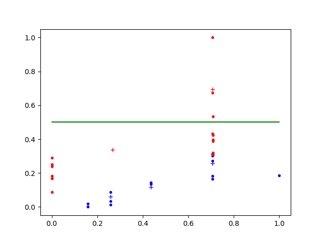

X軸を排気量、Y軸を価格に（0〜1の数値になるように正規化しています）、スーパー・スポーツを赤、そうでない場合を青で描画しています。で、このウネウネと動いている緑の直線こそが、パーセプトロンが学習したスーパー・スポーツかそうでないかの境目なのです！

……えっと、「ちゃちい」とお感じになった皆様、皆様の感覚は正しいです。単純なパーセプトロンだと、データを直線で区切ることしかできないんですよ（重みや入力が3つの場合は、3次元空間上の2次元平面、4つの場合は4次元空間上の3次元の真っ直ぐな何かで二分します）。今回うまく学習できたのは、たまたまデータがパーセプトロンで判別できるものだったからにすぎません。スーパー・スポーツのような高性能なオートバイは排気量あたりの価格が高い（あと、ボッタクリ価格の外車がデータに入っていない）から、直線で分別できただけなんですよ。

たとえば、体重と身長から長生きするかを判断する（身長が低い方が長生きする傾向にあるので直線で区切れそうに思えますけど、痩せすぎも太りすぎも長生きしそうにないので直線では区切れない）ような場合は、単純なパーセプトロンではダメ。複雑な判断が必要な多くの場合では、この単純なパーセプトロンは使用できないんですよ。

## 多層パーセプトロン（の理論）

それはもちろんその通りなのですけど、ただ積み重ねるだけだと、単純なパーセプトロンの出力は0か1のどちらかであるという点が問題となります。重みやバイアスを調整しても出力が0のまま変わらなかったり、ほんの少し調整したら出力が0からいきなり1に変わったりするわけですから、この出力を受け取る次の層のパーセプトロンはとても混乱してしまい、学習どころではなくなってしまうでしょう。そもそも、パーセプトロンへの入力は実数なのですから、パーセプトロンからの出力が0または1だったら積み重ねようがありませんしね。

というわけで、パーセプトロンの出力を実数にしてみます。以下のような感じでしょうか？

```python
def perceptron(*xs):
    return sum(x * weight for x, weight in zip(xs, weights)) + bias
```

残念！ これだけではまだダメです。これだけだと、層を増やしても能力が上がらないらしいんですよ（私の数学力では、理由は全く分からなかったけど）。どこかに非線形な要素を追加しないとダメなんだってさ。

うん、なだらかかつ非線形ですな。ギャップがなくて直線じゃあないですもん。

あと、活性化関数にはもう一つ特徴が必要で、それは「微分できる」ことなんだそうです。重みやバイアスをどの程度変えたらどのように出力が変わるのかが微分で分かるみたいで、そうすれば積み重ねたニューロンを、前の層へ、出力から入力へと逆に調整していくことが可能になるんです。このような、微分をうまいこと使って誤差を逆向きに伝播させて学習させる方式を、逆誤差伝播学習法（バックプロパゲーション）と呼びます。

このような、出力を実数にして活性化関数を間に挟んで、逆誤差伝播学習法に類する方法で複数層のニューロンを学習させるという方式が、1960年代という大昔に発明されました。ただ、当時のコンピューターは貧弱すぎて、逆誤差伝播学習法はまともに動かなかったみたい。使えないものだからみんなすぐに忘れ、また誰かが再発明してまたみんなに忘れられ……という可哀想な運命を辿った挙句、1986年にラメルハートさんとその仲間たちが逆誤差伝播学習法と名づけたあたりで、コンピューターの性能が追いついてやっと定着したみたい。

実は、ReLUはとても優れた活性化関数です。勾配消失が発生しづらく、ニューロンを多段に重ね合わせることができます。単純なので、速く計算できます。あと、何といってもコードが簡単です。だから、活性化関数としてReLUを組み込んだパーセプトロンのコードなら、私ごときでもすぐに作成できます。

```python
def perceptron(*xs):
    return max(0, sum(x * weight for x, weight in zip(xs, weights)) + bias)
```

……`max(0, ...)`を追加しただけです。`max(0, ...)`はとても簡単なコードですけど、これだけで先程のReLUの図になるでしょ？

ともあれ、これで逆誤差伝播学習法で学習させられる「多層パーセプトロン」が完成しました（対比のために、前節で述べたパーセプトロンは「単純パーセプトロン」と呼ばれます）。

実は、深層学習は、この多層パーセプロトンを逆誤差伝播学習法で学習させるところから始まっています（当時はReLUはなかったけど）。で、逆誤差伝播学習法が発表された1986年というのは、ファミリー・コンピューター用のドラゴンクエストIが発売された年なんです。2017年にPlay Station 4でファイナル・ファンタジーXVをやっている私達から見れば、旧世代のカンタンな技術なんですよ。